# The R Package equateIRT: A Tutorial

# 1 Functionalities

The equateIRT package computes:

- **Direct equating coefficients** (between two forms with common items).
- **Chain equating coefficients** (through a chain of forms with common items in pairs).
- **Average (bisector) equating coefficients** (between two forms connected through more than one path).
- **Equated scores** with **true score equating** and **observed score equating** methods.
- **Standard errors** of all equating coefficients and equated scores.
- **Test for DIF** and **tests for drifts**.

# 2 Data preparation

Load the package equateIRT and the data

```r
library("equateIRT")
data("data2pl", package = "equateIRT")
```

Estimate a two parameter logistic model for 5 data sets with the R package mirt

```r
library("mirt")
m1 <- mirt(data2pl[[1]], SE = TRUE)
m2 <- mirt(data2pl[[2]], SE = TRUE)
m3 <- mirt(data2pl[[3]], SE = TRUE)
m4 <- mirt(data2pl[[4]], SE = TRUE)
m5 <- mirt(data2pl[[5]], SE = TRUE)
```

Create an object of class `modIRT` (since package versione 2.5.0 it is possible to skip the import.mirt function)

```r
mlist<- list(m1, m2, m3, m4, m5)
test <- paste("test", 1:5, sep = "")
mod2pl <- modIRT(est.mods = mlist, names = test, display = FALSE)
coef(mod2pl$test1)[1:5]
```

```
##    Dffclt.I1    Dffclt.I2    Dffclt.I3    Dffclt.I4    Dffclt.I5
##  0.058224616  0.028019255  0.073234265  0.415936521 -0.006686047
```

The linkage plan

```r
lplan<-linkp(mods = mod2pl)
lplan
```

```
##      [,1] [,2] [,3] [,4] [,5]
## [1,]   20   10    0    0   10
## [2,]   10   20   10    0    0
## [3,]    0   10   20   10    0
## [4,]    0    0   10   20   10
## [5,]   10    0    0   10   20
```

A graphic of the linkage plan with package `sna`

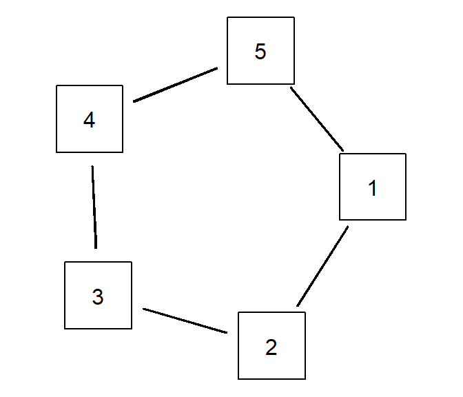

Linkage plan

```r
library(sna)
par(mar=c(0, 0, 0, 0))
set.seed(6)
gplot(lplan, displaylabels = TRUE,  vertex.sides = 4, vertex.cex = 5, vertex.rot =45,  usearrows = FALSE, label.pos = 5, label.cex = 1, vertex.col = 0)
```

# 3 Direct equating coefficients

Estimation of direct equating coefficients between Forms 1 and 2 using the mean-mean method.

**NOTE: Item parameters are converted to the scale of Form 2.**

```r
l12 <- direc(mods = mod2pl, which = c(1,2), method = "mean-mean")
l12
```

```
## Direct equating coefficients
## Method: mean-mean
## Link: test1.test2
```

```r
summary(l12)
```

```
## Link: test1.test2
## Method: mean-mean
## Equating coefficients:
##   Estimate   StdErr
## A  1.21061 0.028998
## B -0.14242 0.028106
```

Estimation of all direct equating coefficients between forms with common items using the mean-mean method

```r
direclist2pl <- alldirec(mods = mod2pl, method = "mean-mean")
direclist2pl
```

```
## Direct equating coefficients
## Method: mean-mean
## Links:
## test1.test2
## test1.test5
## test2.test1
## test2.test3
## test3.test2
## test3.test4
## test4.test3
## test4.test5
## test5.test1
## test5.test4
```

Direct equating coefficients for Forms 1 and 2

```r
summary(direclist2pl, link="test1.test2")
```

```
## Link: test1.test2
## Method: mean-mean
## Equating coefficients:
##   Estimate   StdErr
## A  1.21061 0.028998
## B -0.14242 0.028106
```

# 4 Chain equating coefficients

Estimation of all chain equating coefficients of length 4

```r
cec4 <- chainec(r = 4, direclist = direclist2pl)
cec4
```

```
## Chain equating coefficients
## Method: mean-mean
## Paths:
## test4.test5.test1.test2
## test3.test2.test1.test5
## test5.test1.test2.test3
## test4.test3.test2.test1
## test5.test4.test3.test2
## test1.test2.test3.test4
## test1.test5.test4.test3
## test2.test3.test4.test5
## test2.test1.test5.test4
## test3.test4.test5.test1
```

Chain equating coefficients for path {1, 2, 3, 4}

```r
summary(cec4, path="test1.test2.test3.test4")
```

```
## Path: test1.test2.test3.test4
## Method: mean-mean
## Equating coefficients:
##   Estimate   StdErr
## A  1.25371 0.046538
## B -0.49825 0.038497
```

Estimation of all chain equating coefficients of length 4 from Form 1 to Form 4

```r
cec14 <- chainec(r = 4, direclist = direclist2pl, f1 = "test1", f2 = "test4")
cec14
```

```
## Chain equating coefficients
## Method: mean-mean
## Paths:
## test1.test2.test3.test4
```

```r
summary(cec14)
```

```
## Path: test1.test2.test3.test4
## Method: mean-mean
## Equating coefficients:
##   Estimate   StdErr
## A  1.25371 0.046538
## B -0.49825 0.038497
```

Estimation of chain equating coefficient for path {1, 5, 4}

```r
pth <- paste("test", c(1,5,4), sep = "")
chainec154 <- chainec(direclist = direclist2pl, pths = pth)
summary(chainec154)
```

```
## Path: test1.test5.test4
## Method: mean-mean
## Equating coefficients:
##   Estimate   StdErr
## A  1.15964 0.033424
## B -0.40028 0.033072
```

**NOTE: Item parameters are converted to the scale of Form 4.**

# 5 Average equating coefficients

When two forms are linked through more than one path, the equating coefficients can be averaged using the bisector method. Estimation of bisector equating coefficients:

```r
ecall <- c(cec14, chainec154)
fec <- bisectorec(ecall = ecall, weighted = TRUE, unweighted = TRUE)
fec
```

```
## Bisector and weighted bisector equating coefficients
## Method: mean-mean
##
## Link: test1.test4
##  Paths:
##   test1.test2.test3.test4
##   test1.test5.test4
```

```r
summary(fec)
```

```
## Link: test1.test4
## Method: mean-mean
## Equating coefficients:
##                       Path Estimate   StdErr
##  A test1.test2.test3.test4  1.25371 0.046538
##  A       test1.test5.test4  1.15964 0.033424
##  A                bisector  1.20559 0.030635
##  A       weighted bisector  1.18974 0.029330
##  B test1.test2.test3.test4 -0.49825 0.038497
##  B       test1.test5.test4 -0.40028 0.033072
##  B                bisector -0.44814 0.029917
##  B       weighted bisector -0.43163 0.029704
```

Extract the equating coefficients

```r
 eqc(fec)
```

```
##          link                    path        A          B
## 1 test1.test4 test1.test2.test3.test4 1.253712 -0.4982537
## 2 test1.test4       test1.test5.test4 1.159638 -0.4002830
## 3 test1.test4                bisector 1.205588 -0.4481367
## 4 test1.test4       weighted bisector 1.189738 -0.4316305
```

Extract item parameters of two forms being equated in the original scale and item parameters of the first form converted to the scale of the second form.

```r
itm(fec, bistype = "weighted")
```

```
##          Item        test1       test4 test1.as.test4
## 1   Dffclt.I1  0.058224616          NA    -0.36235841
## 2  Dffclt.I10  0.654862838          NA     0.34748486
## 3   Dffclt.I2  0.028019255          NA    -0.39829488
## 4  Dffclt.I21           NA -0.18966258             NA
## 5  Dffclt.I22           NA -0.57151991             NA
## 6  Dffclt.I23           NA -0.97068963             NA
## 7  Dffclt.I24           NA  0.28221916             NA
## 8  Dffclt.I25           NA  0.02656655             NA
## 9  Dffclt.I26           NA -0.12088864             NA
## 10 Dffclt.I27           NA  0.47589388             NA
## 11 Dffclt.I28           NA -0.01063699             NA
## 12 Dffclt.I29           NA -0.93598686             NA
## 13  Dffclt.I3  0.073234265          NA    -0.34450086
## 14 Dffclt.I30           NA  0.54314189             NA
```

[output cut: 66 more lines]

# 6 Equated scores

Equated scores with the true score equating method

```r
score(fec, bistype = "weighted")
```

```
## The following scores are not attainable: 0
```

```
##         theta test4 test1.as.test4       StdErr
## 1  -3.2018628     1       1.015953 5.003132e-02
## 2  -2.4342926     2       1.955948 6.878631e-02
## 3  -1.9548627     3       2.893737 7.874430e-02
## 4  -1.5906884     4       3.841937 8.359716e-02
## 5  -1.2874493     5       4.805130 8.512002e-02
## 6  -1.0206725     6       5.784930 8.446458e-02
## 7  -0.7769609     7       6.781477 8.251528e-02
## 8  -0.5479067     8       7.794013 8.003024e-02
## 9  -0.3275850     9       8.821124 7.769419e-02
## 10 -0.1113201    10       9.860811 7.609765e-02
## 11  0.1050414    11      10.910495 7.564081e-02
## 12  0.3256710    12      11.966967 7.639765e-02
## 13  0.5553007    13      13.026319 7.802189e-02
## 14  0.7999529    14      14.083854 7.975624e-02
## 15  1.0681829    15      15.133999 8.052101e-02
## 16  1.3736059    16      16.170197 7.900210e-02
## 17  1.7410355    17      17.184780 7.366228e-02
## 18  2.2254147    18      18.168749 6.256879e-02
## 19  3.0012603    19      19.111255 4.258250e-02
## 20 42.1302143    20      20.000000 4.009435e-15
```

Equated scores with the observed score equating method

```r
score(fec, method = "OSE", bistype = "weighted")
```

```
##    test4 test1.as.test4     StdErr
## 1      0    -0.01421594 0.03617689
## 2      1     0.95379681 0.05480849
## 3      2     1.90979310 0.06631698
## 4      3     2.86661488 0.07347523
## 5      4     3.83082127 0.07759881
## 6      5     4.80579296 0.07950051
## 7      6     5.79315712 0.07984123
## 8      7     6.79342490 0.07915320
## 9      8     7.80635915 0.07786227
## 10     9     8.83092394 0.07643819
## 11    10     9.86541737 0.07532277
## 12    11    10.90798519 0.07475095
## 13    12    11.95636186 0.07472299
## 14    13    13.00728219 0.07500067
## 15    14    14.05690943 0.07510454
## 16    15    15.10136220 0.07434567
## 17    16    16.13633708 0.07187445
## 18    17    17.15705121 0.06680167
## 19    18    18.15894672 0.05832150
## 20    19    19.13833584 0.04577955
## 21    20    20.09342215 0.02877984
```

A comparison of equated scores obtained with 2 different chains, bisector and weighted bisector methods.

```r
score(chainec154, scores = 17)
```

```
##      theta test4 test1.as.test4     StdErr
## 1 1.741036    17        17.2431 0.09998233
```

```r
score(cec4, path = "test1.test2.test3.test4", scores = 17)
```

```
##      theta test4 test1.as.test4    StdErr
## 1 1.741036    17       17.06712 0.1618202
```

```r
score(fec, bistype = "unweighted", scores = 17)
```

```
##      theta test4 test1.as.test4     StdErr
## 1 1.741036    17       17.15485 0.08281067
```

```r
score(fec, bistype = "weighted", scores = 17)
```

```
##      theta test4 test1.as.test4     StdErr
## 1 1.741036    17       17.18478 0.07366228
```

# 7 Test for DIF

Load the data

```r
data(dataDIF)
```

Create a dataset for each group and estimate a 2PL model for each group using the R package mirt

```r
library(mirt)
data1 <- dataDIF[dataDIF$group == 1, 1:20]
data2 <- dataDIF[dataDIF$group == 2, 1:20]
data3 <- dataDIF[dataDIF$group == 3, 1:20]
mod1 <- mirt(data1, SE = TRUE)
mod2 <- mirt(data2, SE = TRUE)
mod3 <- mirt(data3, SE = TRUE)
```

Perform the test for DIF on two groups

```r
res_diftest2 <- dif.test(est.mods = list(mod1, mod2))
res_diftest2
```

```
##
##   Test for Differential Item Functioning
##
## Item parameters tested for DIF: intercept and slope
## Equating method used: mean-mean
## Reference group: T1  Focal group: T2
## Item purification not applied
##
##     statistic  p.value
## I01    38.605 4.14e-09 ***
## I02     1.954    0.376
## I03     3.888    0.143
## I04     0.025    0.988
## I05     1.753    0.416
## I06     1.291    0.524
## I07     3.433    0.180
## I08     0.181    0.914
## I09     0.686    0.710
## I10     0.517    0.772
## I11     3.237    0.198
## I12     0.891    0.640
## I13     0.464    0.793
## I14     1.296    0.523
## I15     1.591    0.451
## I16     0.962    0.618
## I17     2.856    0.240
## I18     0.159    0.924
## I19     0.627    0.731
## I20     1.861    0.394
## ---
## Signif. codes: 0 '***' 0.001 '**' 0.01 '*' 0.05 '.' 0.1 ' ' 1
```

Perform the test for DIF on three groups

```r
res_diftest3 <- dif.test(est.mods = list(mod1, mod2, mod3))
res_diftest3
```

```
##
##   Test for Differential Item Functioning
##
## Item parameters tested for DIF: intercept and slope
## Equating method used: mean-mean
## Reference group: T1  Focal groups: T2, T3,
## Item purification not applied
##
##     statistic p.value
## I01   164.585  <2e-16 ***
## I02     3.331   0.504
## I03     4.862   0.302
## I04     5.300   0.258
## I05     3.368   0.498
## I06     1.323   0.858
## I07     4.605   0.330
## I08     1.556   0.817
## I09     1.449   0.836
## I10     4.122   0.390
## I11     3.874   0.423
## I12     5.300   0.258
## I13     2.859   0.582
## I14     2.770   0.597
## I15     3.640   0.457
## I16     4.158   0.385
## I17     5.924   0.205
## I18     2.080   0.721
## I19     2.123   0.713
## I20     7.399   0.116
## ---
## Signif. codes: 0 '***' 0.001 '**' 0.01 '*' 0.05 '.' 0.1 ' ' 1
```

It is possible to change the reference group, the equating method used, and to apply purification.

```r
res_diftest3 <- dif.test(est.mods = list(mod1, mod2, mod3), reference = 2,
                         method = "Haebara", purification = TRUE)
res_diftest3
```

```
##
##   Test for Differential Item Functioning
##
## Item parameters tested for DIF: intercept and slope
## Equating method used: Haebara
## Reference group: T2  Focal groups: T1, T3,
## Item purification applied. Significance level =  0.05
##
##     statistic p.value
## I01   168.026  <2e-16 ***
## I02     2.553   0.635
## I03     2.921   0.571
## I04     4.263   0.372
## I05     3.395   0.494
## I06     0.648   0.958
## I07     2.796   0.592
## I08     2.796   0.593
## I09     1.668   0.796
## I10     2.405   0.662
## I11     1.972   0.741
## I12     4.116   0.391
## I13     1.721   0.787
## I14     2.381   0.666
## I15     4.668   0.323
## I16     2.148   0.709
## I17     4.457   0.348
## I18     1.301   0.861
## I19     2.900   0.575
## I20     3.497   0.478
## ---
## Signif. codes: 0 '***' 0.001 '**' 0.01 '*' 0.05 '.' 0.1 ' ' 1
```

# 8 Tests for drifts

The identity test performs a statistical test to verify if the chain equating coefficients from one form to itself are A=1 and B=0.

```r
data(est3pl)
test <- paste("test", 1:5, sep = "")
mod3pl <- modIRT(coef = est3pl$coef, var = est3pl$var, names = test, display = FALSE)
direclist3pl <- alldirec(mods = mod3pl, method = "Haebara")
pth3 <- paste("test", c(1:5,1), sep = "")
chainec_circle <- chainec(direclist = direclist3pl, pths = pth3)
summary(chainec_circle)
```

```
## Path: test1.test2.test3.test4.test5.test1
## Method: Haebara
## Equating coefficients:
##    Estimate   StdErr
## A 1.0868759 0.063585
## B 0.0022126 0.041833
```

```r
id.test(chainec_circle)
```

```
##
##   Identity test
##
## path:  test1.test2.test3.test4.test5.test1
## statistic = 2.349279, df = 2, p-value = 0.3089304
```

The null hypothesis A=1 and B=0 is not rejected.

It is also possible to performs a statistical test to verify if the chain equating coefficients that link the same two forms are equal.

In the following example test 1 and 5 are linked through two different paths giving two different pairs of equating coefficients. The example uses the 3PL models and the Haebara method, though other options are possible.

```r
pth3 <- paste("test", 1:5, sep = "")
chainec3 <- chainec(direclist = direclist3pl, pths = pth3)
ecall <- c(chainec3, direclist3pl["test1.test5"])
summary(chainec3)
```

```
## Path: test1.test2.test3.test4.test5
## Method: Haebara
## Equating coefficients:
##   Estimate   StdErr
## A  1.06595 0.056590
## B -0.50368 0.042982
```

```r
summary(direclist3pl$test1.test5)
```

```
## Link: test1.test5
## Method: Haebara
## Equating coefficients:
##   Estimate   StdErr
## A  1.00935 0.029052
## B -0.51886 0.027863
```

```r
sd.test(ecall)
```

```
##
##   Scale drift test
##
## link:  test1.test5
## statistic = 1.623208, df = 2, p-value = 0.4441452
```

The null hypothesis of equality of the equating coefficients is not rejected.